Vamsi Gudipati

Portfolio · Latent dynamics · October 2026

# Compress, structure, evolve: autoencoders, a VAE and a Koopman autoencoder on one wake flow

One thousand snapshots of the flow past two plates, 16,384 numbers each. On a random split a convolutional autoencoder keeps them in ten numbers with 0.44 of the fluctuation missed, against 0.76 for ten POD modes scored on the same snapshots, and a variational autoencoder does the same with a latent space that can be sampled. Fitted on the first 800 snapshots and scored on the last 200, the same kind of autoencoder misses 0.96 against POD's 0.79: the advantage was interpolation between neighbours. The third job fails on both splits: a Koopman autoencoder, a linear step learned in that latent space, is worse than the mean flow from the first step of a rollout on a held-out block, and when a five-step loss and a spectral penalty make it stable, it forecasts the mean. DMD, a least-squares fit on ten POD coefficients, is the better forecast at every horizon.

**Vamsi Gudipati** Autoencoders · Variational autoencoders · Koopman operators · POD and DMD [Repository](https://github.com/vamsigudipati/latent-dynamics-ae-vae-koopman)

0.437 vs 0.757

convolutional autoencoder against POD at 10 numbers on a random split, same validation snapshots

0.961 vs 0.788

dense autoencoder against POD at 10 numbers on a split in time: the advantage reverses

0.448 ± 0.015

the VAE at d = 10: below the autoencoder beyond the seed range

0.531 vs 0.366

Koopman one-step error against persistence: no forecast

1.11 vs 1.10

stabilised Koopman model against DMD at 50 steps: DMD wins at every horizon

## Objective

A flow field is thousands of numbers per snapshot, and most of them are redundant: the wake behind a body repeats itself, with variations. A reduced-order model lives on a handful of numbers instead. This project follows one dataset through the three jobs such a model has to do: compress each snapshot into a few numbers, give those numbers a structure that can be sampled, and evolve them in time. Every stage is measured against the linear method that does the same job without a neural network. The work is five stages, each a notebook:

1. **Stage 1 — Compressing a flow field: dense and convolutional autoencoders against POD.** 1,000 snapshots of (u, v) on a 128 × 64 grid, 16,384 numbers each, compressed to 10 by a dense and a convolutional autoencoder, against proper orthogonal decomposition (POD) with 10 modes.
2. **Stage 2 — Structuring the latent space: latent size, trajectories and a variational autoencoder.** How the error falls with the latent size from 2 to 50, what the latent coordinates trace over time, and a variational autoencoder (VAE) whose latent space is pulled towards a normal distribution so that it can be sampled.
3. **Stage 3 — Evolving the latent state: a Koopman autoencoder against persistence and DMD.** An encoder, a 10 × 10 matrix and a decoder trained together so that one matrix multiplication steps the flow forward, against persistence and dynamic mode decomposition (DMD).
4. **Stage 4 — Latent size and rollouts: what the networks buy over POD and DMD.** The same comparisons on equal terms: POD fitted on the training snapshots only and scored on the same validation set as the networks, and the rollouts on a block of time held out entirely, against DMD, persistence and the mean flow.
5. **Stage 5 — A Koopman model trained to forecast, and compression on a split in time.** The Koopman autoencoder given what Stage 4 said it lacked, a contiguous split, a five-step loss and a penalty on eigenvalues outside the unit circle, and the compression comparison repeated with the autoencoder fitted on snapshots 0 to 799 and scored on 800 to 999.

Every training is repeated with seeds 0, 1 and 2, seed 0 being the base run, and a difference counts as an effect only when it exceeds the seed spread. The dataset is a 2-D simulation of viscous flow past two collinear plates at Reynolds number 100.

## Problem statement

Three questions, one per job. How much better than the best linear compression is a nonlinear one of the same size, and does the answer survive a change of seed? What does forcing the latent space towards a normal distribution cost in reconstruction, and what does it buy in sampling? And can a linear operator learned in that latent space forecast the flow at all, measured against the forecast that costs nothing (the last snapshot) and against DMD, the linear method that uses the same ten numbers?

[figure not shown]

**Compress, structure, evolve.** One file of 1,000 snapshots; each job has a neural method and a linear reference of the same size, and the forecast is judged on a held-out block of time against persistence, DMD and the mean flow.

[figure not shown]

**How the stages connect.** No file passes between them: each stage loads the same dataset, and what carries over is code (the dense encoder and decoder builders, the split, the POD and the error function) and method. Stage 4 rebuilds the pieces it needs and runs them with three seeds.

[figure not shown]

**What is held out, and when it changed.** Stages 1 to 3 use a random 800 / 200 split of the snapshots, so 190 of the 200 validation snapshots have a training neighbour one step away, and in Stage 3 160 of the 200 validation targets are also training inputs. Stage 4b fits on snapshots 0 to 799 and rolls out from 150 starts in the held-out block, with the normalisation statistics taken from the fitting period only.

## Method

### Compression against the linear reference

After the time mean is removed, POD by singular value decomposition gives the best linear basis of rank d: the d patterns that capture most of the snapshots' variance. The autoencoders learn a nonlinear map to d numbers and back, trained on mean squared error with Adam, early stopping after 20 flat epochs and the learning rate halved after 8. The error everywhere is the relative L2 error of the reconstruction, per snapshot and velocity component, averaged over the snapshots scored.

[figure not shown]

**Two autoencoders, one latent size.** The dense one flattens the field and carries 16.8 million weights, almost all in its two 512-unit layers; the convolutional one uses a 3 × 3 convolution, pooling and upsampling, but 1.38 million of its 1.39 million weights still sit in the dense bottleneck, so its size depends on the resolution after all.

### A latent space with a distribution

[figure not shown]

**The VAE's encoder** outputs a mean and a log-variance per latent coordinate; a sample z is drawn with the reparameterisation trick so that gradients flow through the draw. The decoder is the same as the autoencoder's.

[figure not shown]

**One training step.** The loss is the summed squared reconstruction error plus β times the KL divergence between the encoder's distribution and the standard normal, β = 0.001; the comparison with the autoencoder decodes the mean, not a sample.

### A linear step in the latent space

[figure not shown]

**The Koopman autoencoder.** An encoder φ to 10 numbers, a 10 × 10 matrix A with no bias, and a decoder ψ called twice: on z(t) for the reconstruction and on A z(t) for the one-step prediction. The two mean squared errors are summed with equal weight.

The idea is Koopman's: a nonlinear system can look linear in the right coordinates, and the encoder is asked to find them. The eigenvalues of A then say how each latent direction decays or grows per step, and a rollout is one encode, n matrix products and one decode. DMD is the linear reference: project the snapshots on 10 POD modes and fit the least-squares matrix that steps those coefficients forward. Persistence predicts the last snapshot; the mean flow predicts zero fluctuation, which gives a relative error of exactly 1, the line that any forecast has to stay under.

[figure not shown]

**A rollout.** Encode the start once, apply A n times, decode once. Stage 3 compares its rollout with the first 50 snapshots rather than with the true futures of its starts, a slip of the original notebook that Stage 4 corrects.

### Which device

[figure not shown]

**One training step of each network inside `model.fit`, CPU against the Apple GPU** (batch 32, median of 30 steps after 10 warm-up steps, log scale). Dense networks are about twice as fast on the GPU; the convolutional ones are 11 to 17 times faster on the CPU.

Each network trains on its faster device, with one exception that the timing did not predict: Stage 1 runs entirely on the CPU, because with the GPU visible its convolutional autoencoder, although pinned to the CPU, ran at 6 seconds per epoch instead of 1 and would have passed my 45-minute limit per training. GPU trainings repeated to every printed digit for a given seed.

## Implementation

What was run, and with what.

[output not shown]

## Results 1 — Ten numbers for a snapshot (Stage 1)

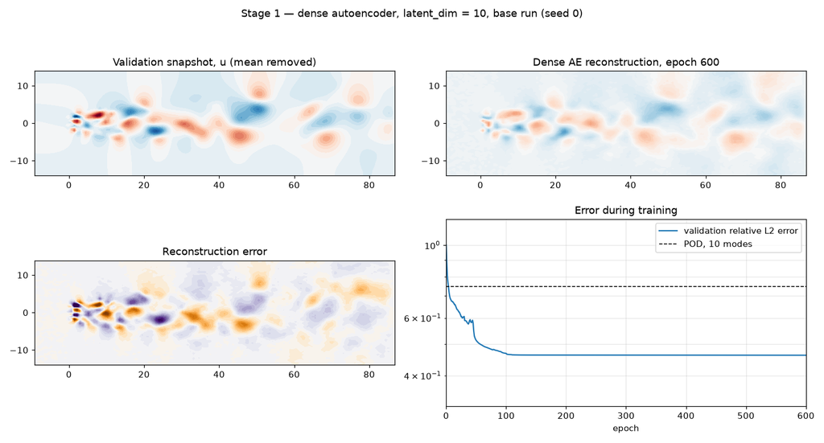

**The dense autoencoder learning a validation snapshot.** After 600 epochs its reconstruction keeps the large structures of the wake and smooths the small ones; its validation error drops below POD's within the first few epochs and settles at about 0.46.

[figure not shown]

**Error at d = 10, three seeds.** The convolutional autoencoder is lower than the dense one in every seed, by more than both ranges. POD of the same rank is far above either.

Mean relative L2 error over the 200 validation snapshots; POD numbers are deterministic.

| Model, d = 10 | Validation error, 3 seeds |
| --- | --- |
| POD, fitted on all snapshots, scored on all | 0.748 |
| POD, training basis, scored on validation | 0.757 |
| Dense autoencoder | 0.465 ± 0.009 |
| Convolutional autoencoder | 0.437 ± 0.006 |
| Convolutional, two blocks, 100 epochs | 0.403 ± 0.018 |

Ten POD modes miss three quarters of the fluctuation; ten latent numbers of an autoencoder miss less than half. The convolutional network does this with 12 times fewer weights, and a second block at a sixth of the epochs is lower again, though with a wider spread.

The error field shows where the ten numbers fall short: the fine structure near the plates and the smaller eddies downstream, which no ten-dimensional description keeps. What the autoencoder keeps better than POD is the placement and shape of the large structures.

[figure not shown]

**Training curves of the base run.** Both validation losses flatten after about 100 epochs, yet neither training stopped early: both ran to the 600-epoch cap, the dense one with its learning rate halved down to 1e-6 and its lowest validation value at the last epoch. The original notebook's text says the validation loss stops improving around epoch 40 to 50 and early stopping restores the best weights; in this run neither happened.

What a latent coordinate means is the other finding of this stage. Decoding a 2 σ step along each latent direction gives a field, but those fields are sensitivities of the decoder, not modes: they do not add up to the snapshot and they are not orthogonal, so the ordered, additive structure of POD is the price of the lower error.

## Results 2 — The latent space, and a VAE (Stage 2)

[figure not shown]

**Error against latent size, 2 to 50.** The autoencoders are below POD at every size from 5 up; at d = 2 everything is near 0.9. At d = 10 the VAE and the convolutional VAE both sit below the sweep's autoencoder, and an autoencoder trained with patience 20 instead of the 150-epoch cap gains little. Lines and markers: mean of three seeds with the range.

Stage 4a: all four columns scored on the same 200 validation snapshots; networks are the mean of three seeds, 150-epoch budget, dropout 0.1.

| d | POD, all snapshots | POD, training basis | Dense AE | VAE |
| --- | --- | --- | --- | --- |
| 2 | 0.922 | 0.918 | 0.902 ± 0.010 | 0.897 ± 0.009 |
| 5 | 0.837 | 0.834 | 0.764 ± 0.005 | 0.753 ± 0.008 |
| 10 | 0.748 | 0.757 | 0.499 ± 0.018 | 0.448 ± 0.015 |
| 20 | 0.604 | 0.614 | 0.357 ± 0.005 | 0.306 ± 0.004 |
| 50 | 0.392 | 0.417 | 0.296 | 0.313 ± 0.081 |

The VAE beats the plain autoencoder at d = 5, 10 and 20 in every seed, but beyond both seed ranges only at 10 and 20; at d = 2 and 50 there is no effect, and at 50 one VAE seed is far off. The autoencoders' seeds 1 and 2 of this table reproduce Stage 2's own seed runs exactly, so they are the same trainings counted once, not independent repeats.

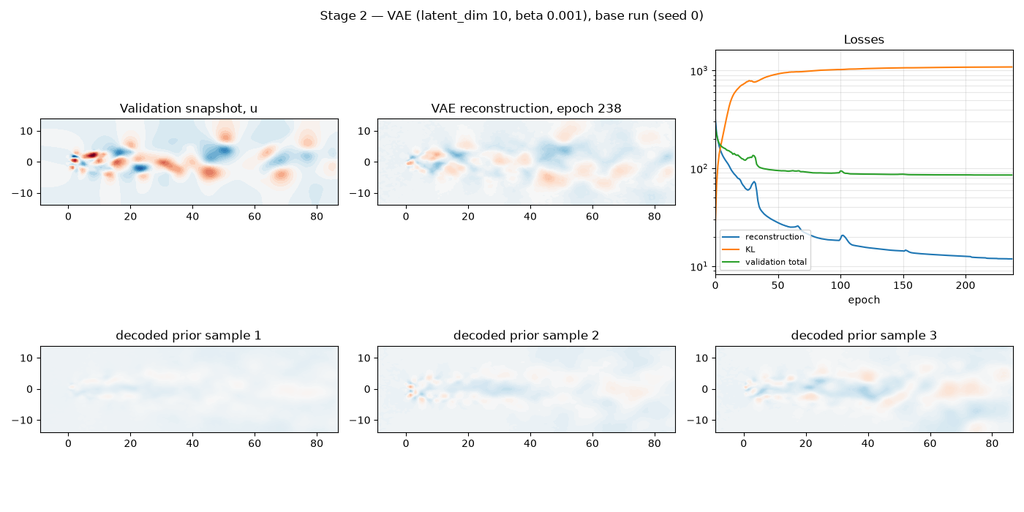

**The VAE's base run.** Its reconstruction (decoded from the mean) matches the autoencoder's quality, and the KL term grows to about a thousand while β keeps its weight small. The three fields decoded from draws z ~ N(0, I) are faint: each is plotted on its own colour scale in the original notebook, which makes them look more realistic than they are.

[figure not shown]

**β decides the trade.** At 1e-5 and 1e-3 the VAE reconstructs as well as an autoencoder; at 0.1 it loses a little and at 1 a lot. The β = 1 model scored 0.449 in an earlier run and 0.641 ± 0.017 here.

[figure not shown]

**The VAE's losses.** The validation reconstruction term ends seven times the training one, 84 against 12 per snapshot: the model fits the 800 training snapshots far more closely than the 200 it has not seen.

At β = 0.001 the prior samples carry about 4 % of the real fluctuation energy. A latent space that reconstructs well and one that generates well are two different settings of the same knob, and this dataset of 1,000 snapshots does not give both at once.

## Results 3 — A linear step that does not forecast (Stage 3)

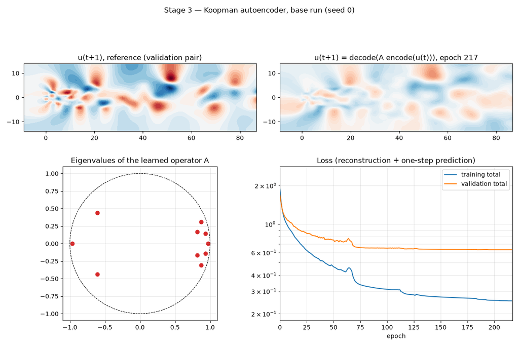

**The base run after 217 epochs.** The one-step prediction keeps the wake's layout and loses its amplitude; all ten eigenvalues of A sit inside the unit circle in this seed; the validation loss is two and a half times the training loss.

[figure not shown]

**One-step error on the 200 validation pairs.** The Koopman autoencoder's prediction is worse than persistence in every seed and better than DMD; a nonlinear operator in place of A is worse still.

Relative error on the standardised field; persistence and DMD are deterministic.

| Model | One-step error, 200 validation pairs |
| --- | --- |
| Persistence | 0.366 |
| Koopman AE, reconstruction | 0.525 ± 0.017 |
| Koopman AE, prediction | 0.531 ± 0.017 |
| Nonlinear operator in place of A | 0.605 ± 0.018 |
| DMD, rank 10 | 0.721 |
| Mean flow | 1 |

The prediction error is almost the reconstruction error: the operator adds only 0.006, so what the model loses, it loses in the encoder and decoder, not in the step. But a model that cannot beat the last snapshot is not a forecast, and the random split flatters it: 160 of its 200 validation targets are training inputs.

The reconstruction term of the loss dominates the training, and the two-and-a-half-fold gap between validation and training loss says the encoder and decoder overfit the 799 training pairs. A linear operator can only be as good as the coordinates it is given.

[figure not shown]

**Eigenvalues of the learned operator against the unit circle.** Left: the base run, all inside; right: the largest modulus of each run. Seed 0 gives 0.969, seed 2 gives 1.069, and the earlier run of the same notebook gave 1.013: whether the learned dynamics are stable depends on the seed.

Two more things about this stage are worth stating. Standardising every grid point by its own standard deviation magnifies near-still points upstream of the plates by up to 20,000 times, which is a strange thing to ask a decoder to match. And the notebook's rollout compares its predictions with the first 50 snapshots, not with the true futures of its 50 starts, so its rollout curve measures nothing; Stage 4 does the rollout properly.

## Results 4 — On equal terms, and on a held-out block (Stage 4)

### Compression, on the same snapshots

[figure not shown]

**POD, dense autoencoder and VAE scored on the same 200 validation snapshots.** POD fitted on the training set only lands within 0.03 of the all-snapshot POD of Stages 1 and 2 at every size (slightly below it at 2 and 5, above it from 10), so the networks' advantage was not an artefact of the scoring; it widens from 5 to 20 and narrows again at 50.

On this split the compression result stands. At d = 10, POD on a training basis scores 0.757 against the autoencoder's 0.499 and the VAE's 0.448, and the VAE's edge over the autoencoder at 10 and 20 exceeds the seed range. But the split is still a random one, in which almost every validation snapshot has a training neighbour one step away; Stage 5 repeats the comparison on a split in time, and the answer changes.

### Forecasting, on a block of time the models never saw

[figure not shown]

**Left: rollout error against steps ahead, 150 held-out starts.** The Koopman autoencoder (mean of three seeds, band the range) is above 1, the mean-flow line, from the first step; DMD stays below 1 until about 30 steps; persistence is excellent for two steps and then oscillates with the wake. **Right: the modulus of every eigenvalue.** DMD's ten are all inside the circle; the Koopman operator's are inside for seed 0 and outside for two values in seed 1 and one in seed 2.

Relative error of the predicted fluctuation; fitting on snapshots 0 to 799, 150 starts in the held-out block, normalisation from the fitting period.

| Steps ahead n | Koopman AE (3 seeds) | DMD, 10 POD coefficients | Persistence | Mean flow |
| --- | --- | --- | --- | --- |
| 1 | 1.013 [0.999, 1.026] | 0.833 | 0.401 | 1 |
| 2 | 1.229 [1.098, 1.384] | 0.840 | 0.733 | 1 |
| 5 | 1.267 [1.083, 1.425] | 0.867 | 1.305 | 1 |
| 10 | 1.299 [1.118, 1.508] | 0.913 | 1.587 | 1 |
| 20 | 1.369 [1.044, 1.539] | 0.976 | 1.206 | 1 |
| 50 | 1.423 [1.075, 1.700] | 1.096 | 1.337 | 1 |

The Koopman autoencoder does not forecast this flow. On starts it has never seen it is worse than predicting the mean flow from the very first step, and in the three-seed mean it is worse than DMD at every horizon up to 50 steps (1.42 against 1.10 at 50); only seed 0 alone drops below DMD, from step 36, where both are already above 1. DMD, a least-squares fit on ten POD coefficients with no training, is the best forecast beyond two steps and stays below the mean-flow line for about 30.

The eigenvalues explain the growth. DMD's largest modulus is 0.998, so its rollout decays slowly towards the mean; the learned operator has eigenvalues outside the unit circle in two of three seeds, so those rollouts grow. Nothing in the training loss asks the operator to be stable, and a one-step loss on a random split does not reward it either.

## Results 5 — Trained to forecast, and compression on a split in time (Stage 5)

### Three Koopman autoencoders on the contiguous split

Stage 4 named what the Koopman autoencoder lacked: a contiguous split, a loss that looks further than one step, and something that keeps the operator stable. Stage 5 gives it all three. Model (i) is Stage 3's one-step model refitted on snapshots 0 to 799; model (ii) applies A five times and sums the five prediction errors; model (iii) adds a penalty on every eigenvalue modulus above 1, weighted so that an excursion of 0.05 costs as much as the untrained prediction loss. All three roll out from the same 150 held-out starts as Stage 4.

[figure not shown]

**Model (iii).** The encoder and decoder of Stage 3; the 10 × 10 operator applied five times in a row with one decoder for all six outputs; the spectral penalty evaluated on A at every training step.

[figure not shown]

**Rollout error against steps ahead, 150 held-out starts.** The one-step model climbs above 1.4; the multi-step models hover between 1.0 and 1.2; DMD is the only line below the mean flow for more than a step or two.

Mean relative error of the predicted fluctuation over three seeds; the mean flow scores exactly 1. Model (i) reproduces Stage 4's rollout to four decimals.

| Steps ahead n | (i) one-step loss | (ii) five-step loss | (iii) five-step + penalty | DMD | Persistence |
| --- | --- | --- | --- | --- | --- |
| 1 | 1.013 | 1.013 | 0.998 | 0.833 | 0.401 |
| 2 | 1.229 | 1.013 | 0.993 | 0.840 | 0.733 |
| 5 | 1.267 | 1.028 | 1.006 | 0.867 | 1.305 |
| 10 | 1.299 | 1.089 | 1.072 | 0.913 | 1.587 |
| 20 | 1.369 | 1.155 | 1.195 | 0.976 | 1.206 |
| 50 | 1.423 | 1.204 | 1.111 | 1.096 | 1.337 |
| Largest \|λ\|, seeds 0, 1, 2 | 0.990, 1.016, 1.011 | 1.016, 1.009, 1.006 | 0.9999, 0.9998, 1.0000 | 0.998 | — |

[figure not shown]

The multi-step loss removes the growth: the error stays within 1.0 to 1.2 instead of climbing to 1.4, with a seed range a tenth of before. The penalty then brings every eigenvalue to the circle, and the model is below the mean flow in all three seeds at one horizon. But no model beats DMD at any of the 50 horizons, and the reason is visible in the numbers: a rollout error that settles near 1 is a forecast of the mean flow. The multi-step models have learned to let the latent state decay rather than to follow the wake, which is what a squared-error loss over several steps rewards when the dynamics are hard to track.

### Compression, on a split in time

[figure not shown]

**POD against the dense autoencoder at d = 10, on two kinds of split.** Fitted on snapshots 0 to 799 and scored on 800 to 999, POD with a training basis scores 0.79 and the autoencoder 0.96; on the random split of the earlier stages the same autoencoder scored 0.46 to 0.50 against POD's 0.76.

Mean relative L2 error at d = 10; the time-split autoencoder uses Stage 1's builder and ran to the 600-epoch cap in every seed.

| Split | POD, training basis | Dense autoencoder, 3 seeds (range) |
| --- | --- | --- |
| In time: fit 0 – 799, score 800 – 999 | 0.7875 | 0.9611 (0.9526 – 0.9654) |
| Random 800 / 200 (Stage 4) | 0.7572 | 0.4992 (0.4786 – 0.5131) |
| Random 800 / 200 (Stage 1) | 0.7572 | 0.4649 (0.4578 – 0.4756) |

This is the result that changes the page. On snapshots the autoencoder has never been near, it misses 0.96 of the fluctuation, worse than ten POD modes by 0.17 with a seed range of 0.013, and barely better than predicting the mean. POD moves by 0.03 between the two splits; the autoencoder moves by 0.46. The random split's validation snapshots each sit one step from a training snapshot, and the autoencoder's advantage in Stages 1, 2 and 4 was largely an advantage at interpolating between neighbours it had seen. Ten POD modes, being the best linear basis of the training period, generalise to new wake positions; the ten learned coordinates do not.

## Conclusion

What the stages do not establish: whether a larger latent size, a longer multi-step horizon or a loss on the latent trajectory would give a Koopman model that beats DMD, none of which was tried; whether the convolutional autoencoder and the VAE suffer the same reversal on a split in time, since only the dense autoencoder was retested; and whether the VAE's generated fields improve with more snapshots or a β schedule. The next steps are the compression sweep on the contiguous split for all three architectures, a Koopman model with a trajectory loss in the latent space, and a longer dataset for the VAE.

## Code, data and reproducibility

The five notebooks of the repository, each also exported as HTML with all outputs.

| Notebook | Stage |
| --- | --- |
| `01_autoencoders_and_pod.ipynb` | Stage 1 — Compressing a flow field: dense and convolutional autoencoders against POD |
| `02_latent_space_and_vae.ipynb` | Stage 2 — Structuring the latent space: latent size, trajectories and a variational autoencoder |
| `03_koopman_autoencoder.ipynb` | Stage 3 — Evolving the latent state: a Koopman autoencoder against persistence and DMD |
| `04_rollout_and_baselines.ipynb` | Stage 4 — Latent size and rollouts: what the networks buy over POD and DMD |
| `05_koopman_trained_to_forecast.ipynb` | Stage 5 — A Koopman model trained to forecast, and compression on a split in time |

[output not shown]